# Sixth Week: Linear Models

House price prediction

Mohammad amin Roohi

2018-04-13 20:13:11

> با توجه به داده های قیمت منازل لطفا با سوالات زیر پاسخ دهید.

۱. ماتریس همبستگی متغیرهای مختلف را به دست آورده و سپس رسم نمایید. اعداد به دست آمده را با آزمون فرض معناداری همبستگی بسنجید و سپس ده متغیری که همبستگی بالاتری با قیمت دارند را مشخص نمایید.

```r
library(readr)
library(corrplot)
library(dplyr)
library(car)
library(ggplot2)
library(gridExtra)
library(Hmisc)
library(knitr)
library(lmtest)
house = read_csv("D:/University/Semester8/Data analysis/week6/house/train.csv")
q = house

q[is.na(q)] <- "0"

n_q <- q[, sapply(q, is.numeric)]


kable(rcorr(as.matrix(n_q))$r)
```

|  | Id | MSSubClass | LotArea | OverallQual | OverallCond | YearBuilt | YearRemodAdd | BsmtFinSF1 | BsmtFinSF2 | BsmtUnfSF | TotalBsmtSF | 1stFlrSF | 2ndFlrSF | LowQualFinSF | GrLivArea | BsmtFullBath | BsmtHalfBath | FullBath | HalfBath | BedroomAbvGr | KitchenAbvGr | TotRmsAbvGrd | Fireplaces | GarageCars | GarageArea | WoodDeckSF | OpenPorchSF | EnclosedPorch | 3SsnPorch | … |
| --- | --- | --- | --- | --- | --- | --- | --- | --- | --- | --- | --- | --- | --- | --- | --- | --- | --- | --- | --- | --- | --- | --- | --- | --- | --- | --- | --- | --- | --- | --- |
| Id | 1.0000000 | 0.0111565 | -0.0332255 | -0.0283648 | 0.0126089 | -0.0127127 | -0.0219976 | -0.0050240 | -0.0059677 | -0.0079397 | -0.0154146 | 0.0104960 | 0.0055898 | -0.0442300 | 0.0082728 | 0.0022886 | -0.0201547 | 0.0055875 | 0.0067838 | 0.0377186 | 0.0029512 | 0.0272387 | -0.0197716 | 0.0165697 | 0.0176338 | -0.0296432 | -0.0004769 | 0.0028892 | -0.0466348 | … |
| MSSubClass | 0.0111565 | 1.0000000 | -0.1397811 | 0.0326277 | -0.0593158 | 0.0278501 | 0.0405810 | -0.0698357 | -0.0656486 | -0.1407595 | -0.2385184 | -0.2517584 | 0.3078857 | 0.0464738 | 0.0748532 | 0.0034910 | -0.0023325 | 0.1316082 | 0.1773544 | -0.0234380 | 0.2817210 | 0.0403801 | -0.0455693 | -0.0401098 | -0.0986715 | -0.0125794 | -0.0061001 | -0.0120366 | -0.0438245 | … |
| LotArea | -0.0332255 | -0.1397811 | 1.0000000 | 0.1058057 | -0.0056363 | 0.0142277 | 0.0137884 | 0.2141031 | 0.1111697 | -0.0026184 | 0.2608331 | 0.2994746 | 0.0509859 | 0.0047790 | 0.2631162 | 0.1581545 | 0.0480456 | 0.1260306 | 0.0142595 | 0.1196899 | -0.0177839 | 0.1900148 | 0.2713640 | 0.1548707 | 0.1804028 | 0.1716977 | 0.0847738 | -0.0183397 | 0.0204228 | … |
| OverallQual | -0.0283648 | 0.0326277 | 0.1058057 | 1.0000000 | -0.0919323 | 0.5723228 | 0.5506839 | 0.2396660 | -0.0591187 | 0.3081589 | 0.5378085 | 0.4762238 | 0.2954929 | -0.0304293 | 0.5930074 | 0.1110978 | -0.0401502 | 0.5505997 | 0.2734581 | 0.1016764 | -0.1838822 | 0.4274523 | 0.3967650 | 0.6006707 | 0.5620218 | 0.2389234 | 0.3088188 | -0.1139369 | 0.0303706 | … |
| OverallCond | 0.0126089 | -0.0593158 | -0.0056363 | -0.0919323 | 1.0000000 | -0.3759832 | 0.0737415 | -0.0462309 | 0.0402292 | -0.1368406 | -0.1710975 | -0.1442028 | 0.0289421 | 0.0254943 | -0.0796859 | -0.0549415 | 0.1178209 | -0.1941495 | -0.0607693 | 0.0129801 | -0.0870009 | -0.0575832 | -0.0238200 | -0.1857575 | -0.1515214 | -0.0033337 | -0.0325888 | 0.0703562 | 0.0255037 | … |
| YearBuilt | -0.0127127 | 0.0278501 | 0.0142277 | 0.5723228 | -0.3759832 | 1.0000000 | 0.5928550 | 0.2495032 | -0.0491068 | 0.1490404 | 0.3914520 | 0.2819859 | 0.0103077 | -0.1837843 | 0.1990097 | 0.1875985 | -0.0381618 | 0.4682708 | 0.2426559 | -0.0706512 | -0.1748002 | 0.0955891 | 0.1477164 | 0.5378501 | 0.4789538 | 0.2248801 | 0.1886858 | -0.3872678 | 0.0313545 | … |
| YearRemodAdd | -0.0219976 | 0.0405810 | 0.0137884 | 0.5506839 | 0.0737415 | 0.5928550 | 1.0000000 | 0.1284505 | -0.0677585 | 0.1811331 | 0.2910656 | 0.2403793 | 0.1400238 | -0.0624191 | 0.2873885 | 0.1194699 | -0.0123370 | 0.4390465 | 0.1833306 | -0.0405809 | -0.1495975 | 0.1917398 | 0.1125813 | 0.4206222 | 0.3715998 | 0.2057259 | 0.2262976 | -0.1939191 | 0.0452858 | … |
| BsmtFinSF1 | -0.0050240 | -0.0698357 | 0.2141031 | 0.2396660 | -0.0462309 | 0.2495032 | 0.1284505 | 1.0000000 | -0.0501174 | -0.4952515 | 0.5223961 | 0.4458627 | -0.1370790 | -0.0645026 | 0.2081711 | 0.6492118 | 0.0674185 | 0.0585431 | 0.0042624 | -0.1073547 | -0.0810069 | 0.0443156 | 0.2600109 | 0.2240535 | 0.2969704 | 0.2043061 | 0.1117606 | -0.1023033 | 0.0264505 | … |
| BsmtFinSF2 | -0.0059677 | -0.0656486 | 0.1111697 | -0.0591187 | 0.0402292 | -0.0491068 | -0.0677585 | -0.0501174 | 1.0000000 | -0.2092945 | 0.1048095 | 0.0971174 | -0.0992603 | 0.0148070 | -0.0096399 | 0.1586781 | 0.0709481 | -0.0764439 | -0.0321478 | -0.0157281 | -0.0407512 | -0.0352265 | 0.0469207 | -0.0382635 | -0.0182266 | 0.0678983 | 0.0030926 | 0.0365433 | -0.0299934 | … |
| BsmtUnfSF | -0.0079397 | -0.1407595 | -0.0026184 | 0.3081589 | -0.1368406 | 0.1490404 | 0.1811331 | -0.4952515 | -0.2092945 | 1.0000000 | 0.4153596 | 0.3179874 | 0.0044691 | 0.0281667 | 0.2402573 | -0.4229005 | -0.0958043 | 0.2888861 | -0.0411175 | 0.1666433 | 0.0300859 | 0.2506471 | 0.0515749 | 0.2141752 | 0.1833027 | -0.0053164 | 0.1290054 | -0.0025379 | 0.0207640 | … |
| TotalBsmtSF | -0.0154146 | -0.2385184 | 0.2608331 | 0.5378085 | -0.1710975 | 0.3914520 | 0.2910656 | 0.5223961 | 0.1048095 | 0.4153596 | 1.0000000 | 0.8195300 | -0.1745120 | -0.0332454 | 0.4548682 | 0.3073506 | -0.0003146 | 0.3237224 | -0.0488037 | 0.0504500 | -0.0689006 | 0.2855726 | 0.3395193 | 0.4345848 | 0.4866655 | 0.2320186 | 0.2472637 | -0.0954777 | 0.0373837 | … |
| 1stFlrSF | 0.0104960 | -0.2517584 | 0.2994746 | 0.4762238 | -0.1442028 | 0.2819859 | 0.2403793 | 0.4458627 | 0.0971174 | 0.3179874 | 0.8195300 | 1.0000000 | -0.2026462 | -0.0142407 | 0.5660240 | 0.2446711 | 0.0019557 | 0.3806375 | -0.1199159 | 0.1274007 | 0.0681006 | 0.4095160 | 0.4105311 | 0.4393168 | 0.4897817 | 0.2354586 | 0.2116712 | -0.0652917 | 0.0561044 | … |
| 2ndFlrSF | 0.0055898 | 0.3078857 | 0.0509859 | 0.2954929 | 0.0289421 | 0.0103077 | 0.1400238 | -0.1370790 | -0.0992603 | 0.0044691 | -0.1745120 | -0.2026462 | 1.0000000 | 0.0633530 | 0.6875011 | -0.1694940 | -0.0238548 | 0.4213780 | 0.6097073 | 0.5029006 | 0.0593058 | 0.6164226 | 0.1945609 | 0.1839256 | 0.1383470 | 0.0921654 | 0.2080261 | 0.0619887 | -0.0243576 | … |
| LowQualFinSF | -0.0442300 | 0.0464738 | 0.0047790 | -0.0304293 | 0.0254943 | -0.1837843 | -0.0624191 | -0.0645026 | 0.0148070 | 0.0281667 | -0.0332454 | -0.0142407 | 0.0633530 | 1.0000000 | 0.1346828 | -0.0471434 | -0.0058415 | -0.0007095 | -0.0270800 | 0.1056066 | 0.0075217 | 0.1311848 | -0.0212721 | -0.0944795 | -0.0676014 | -0.0254436 | 0.0182510 | 0.0610812 | -0.0042956 | … |
| GrLivArea | 0.0082728 | 0.0748532 | 0.2631162 | 0.5930074 | -0.0796859 | 0.1990097 | 0.2873885 | 0.2081711 | -0.0096399 | 0.2402573 | 0.4548682 | 0.5660240 | 0.6875011 | 0.1346828 | 1.0000000 | 0.0348360 | -0.0189185 | 0.6300116 | 0.4157716 | 0.5212695 | 0.1000632 | 0.8254894 | 0.4616791 | 0.4672474 | 0.4689975 | 0.2474328 | 0.3302240 | 0.0091132 | 0.0206432 | … |
| BsmtFullBath | 0.0022886 | 0.0034910 | 0.1581545 | 0.1110978 | -0.0549415 | 0.1875985 | 0.1194699 | 0.6492118 | 0.1586781 | -0.4229005 | 0.3073506 | 0.2446711 | -0.1694940 | -0.0471434 | 0.0348360 | 1.0000000 | -0.1478710 | -0.0645120 | -0.0309050 | -0.1506728 | -0.0415025 | -0.0532752 | 0.1379277 | 0.1318812 | 0.1791895 | 0.1753152 | 0.0673415 | -0.0499106 | -0.0001061 | … |
| BsmtHalfBath | -0.0201547 | -0.0023325 | 0.0480456 | -0.0401502 | 0.1178209 | -0.0381618 | -0.0123370 | 0.0674185 | 0.0709481 | -0.0958043 | -0.0003146 | 0.0019557 | -0.0238548 | -0.0058415 | -0.0189185 | -0.1478710 | 1.0000000 | -0.0545358 | -0.0123399 | 0.0465188 | -0.0379444 | -0.0238363 | 0.0289756 | -0.0208911 | -0.0245356 | 0.0401612 | -0.0253238 | -0.0085553 | 0.0351136 | … |
| FullBath | 0.0055875 | 0.1316082 | 0.1260306 | 0.5505997 | -0.1941495 | 0.4682708 | 0.4390465 | 0.0585431 | -0.0764439 | 0.2888861 | 0.3237224 | 0.3806375 | 0.4213780 | -0.0007095 | 0.6300116 | -0.0645120 | -0.0545358 | 1.0000000 | 0.1363806 | 0.3632520 | 0.1331152 | 0.5547843 | 0.2436705 | 0.4696720 | 0.4056562 | 0.1877032 | 0.2599774 | -0.1150930 | 0.0353530 | … |
| HalfBath | 0.0067838 | 0.1773544 | 0.0142595 | 0.2734581 | -0.0607693 | 0.2426559 | 0.1833306 | 0.0042624 | -0.0321478 | -0.0411175 | -0.0488037 | -0.1199159 | 0.6097073 | -0.0270800 | 0.4157716 | -0.0309050 | -0.0123399 | 0.1363806 | 1.0000000 | 0.2266515 | -0.0682625 | 0.3434149 | 0.2036485 | 0.2191782 | 0.1635494 | 0.1080803 | 0.1997401 | -0.0953165 | -0.0049725 | … |
| BedroomAbvGr | 0.0377186 | -0.0234380 | 0.1196899 | 0.1016764 | 0.0129801 | -0.0706512 | -0.0405809 | -0.1073547 | -0.0157281 | 0.1666433 | 0.0504500 | 0.1274007 | 0.5029006 | 0.1056066 | 0.5212695 | -0.1506728 | 0.0465188 | 0.3632520 | 0.2266515 | 1.0000000 | 0.1985968 | 0.6766199 | 0.1075697 | 0.0861064 | 0.0652525 | 0.0468538 | 0.0938096 | 0.0415704 | -0.0244778 | … |
| KitchenAbvGr | 0.0029512 | 0.2817210 | -0.0177839 | -0.1838822 | -0.0870009 | -0.1748002 | -0.1495975 | -0.0810069 | -0.0407512 | 0.0300859 | -0.0689006 | 0.0681006 | 0.0593058 | 0.0075217 | 0.1000632 | -0.0415025 | -0.0379444 | 0.1331152 | -0.0682625 | 0.1985968 | 1.0000000 | 0.2560454 | -0.1239362 | -0.0506339 | -0.0644330 | -0.0901303 | -0.0700906 | 0.0373124 | -0.0246004 | … |
| TotRmsAbvGrd | 0.0272387 | 0.0403801 | 0.1900148 | 0.4274523 | -0.0575832 | 0.0955891 | 0.1917398 | 0.0443156 | -0.0352265 | 0.2506471 | 0.2855726 | 0.4095160 | 0.6164226 | 0.1311848 | 0.8254894 | -0.0532752 | -0.0238363 | 0.5547843 | 0.3434149 | 0.6766199 | 0.2560454 | 1.0000000 | 0.3261145 | 0.3622886 | 0.3378221 | 0.1659839 | 0.2341916 | 0.0041513 | -0.0066832 | … |
| Fireplaces | -0.0197716 | -0.0455693 | 0.2713640 | 0.3967650 | -0.0238200 | 0.1477164 | 0.1125813 | 0.2600109 | 0.0469207 | 0.0515749 | 0.3395193 | 0.4105311 | 0.1945609 | -0.0212721 | 0.4616791 | 0.1379277 | 0.0289756 | 0.2436705 | 0.2036485 | 0.1075697 | -0.1239362 | 0.3261145 | 1.0000000 | 0.3007888 | 0.2691412 | 0.2000188 | 0.1694053 | -0.0248219 | 0.0112572 | … |
| GarageCars | 0.0165697 | -0.0401098 | 0.1548707 | 0.6006707 | -0.1857575 | 0.5378501 | 0.4206222 | 0.2240535 | -0.0382635 | 0.2141752 | 0.4345848 | 0.4393168 | 0.1839256 | -0.0944795 | 0.4672474 | 0.1318812 | -0.0208911 | 0.4696720 | 0.2191782 | 0.0861064 | -0.0506339 | 0.3622886 | 0.3007888 | 1.0000000 | 0.8824754 | 0.2263421 | 0.2135694 | -0.1514342 | 0.0357653 | … |
| GarageArea | 0.0176338 | -0.0986715 | 0.1804028 | 0.5620218 | -0.1515214 | 0.4789538 | 0.3715998 | 0.2969704 | -0.0182266 | 0.1833027 | 0.4866655 | 0.4897817 | 0.1383470 | -0.0676014 | 0.4689975 | 0.1791895 | -0.0245356 | 0.4056562 | 0.1635494 | 0.0652525 | -0.0644330 | 0.3378221 | 0.2691412 | 0.8824754 | 1.0000000 | 0.2246663 | 0.2414347 | -0.1217767 | 0.0350867 | … |
| WoodDeckSF | -0.0296432 | -0.0125794 | 0.1716977 | 0.2389234 | -0.0033337 | 0.2248801 | 0.2057259 | 0.2043061 | 0.0678983 | -0.0053164 | 0.2320186 | 0.2354586 | 0.0921654 | -0.0254436 | 0.2474328 | 0.1753152 | 0.0401612 | 0.1877032 | 0.1080803 | 0.0468538 | -0.0901303 | 0.1659839 | 0.2000188 | 0.2263421 | 0.2246663 | 1.0000000 | 0.0586606 | -0.1259889 | -0.0327706 | … |
| OpenPorchSF | -0.0004769 | -0.0061001 | 0.0847738 | 0.3088188 | -0.0325888 | 0.1886858 | 0.2262976 | 0.1117606 | 0.0030926 | 0.1290054 | 0.2472637 | 0.2116712 | 0.2080261 | 0.0182510 | 0.3302240 | 0.0673415 | -0.0253238 | 0.2599774 | 0.1997401 | 0.0938096 | -0.0700906 | 0.2341916 | 0.1694053 | 0.2135694 | 0.2414347 | 0.0586606 | 1.0000000 | -0.0930793 | -0.0058425 | … |
| EnclosedPorch | 0.0028892 | -0.0120366 | -0.0183397 | -0.1139369 | 0.0703562 | -0.3872678 | -0.1939191 | -0.1023033 | 0.0365433 | -0.0025379 | -0.0954777 | -0.0652917 | 0.0619887 | 0.0610812 | 0.0091132 | -0.0499106 | -0.0085553 | -0.1150930 | -0.0953165 | 0.0415704 | 0.0373124 | 0.0041513 | -0.0248219 | -0.1514342 | -0.1217767 | -0.1259889 | -0.0930793 | 1.0000000 | -0.0373053 | … |
| 3SsnPorch | -0.0466348 | -0.0438245 | 0.0204228 | 0.0303706 | 0.0255037 | 0.0313545 | 0.0452858 | 0.0264505 | -0.0299934 | 0.0207640 | 0.0373837 | 0.0561044 | -0.0243576 | -0.0042956 | 0.0206432 | -0.0001061 | 0.0351136 | 0.0353530 | -0.0049725 | -0.0244778 | -0.0246004 | -0.0066832 | 0.0112572 | 0.0357653 | 0.0350867 | -0.0327706 | -0.0058425 | -0.0373053 | 1.0000000 | … |
| ScreenPorch | 0.0013302 | -0.0260302 | 0.0431604 | 0.0648864 | 0.0548105 | -0.0503644 | -0.0387400 | 0.0620206 | 0.0888713 | -0.0125793 | 0.0844890 | 0.0887581 | 0.0406064 | 0.0267994 | 0.1015104 | 0.0231477 | 0.0321214 | -0.0081061 | 0.0724258 | 0.0442997 | -0.0516134 | 0.0593826 | 0.1845303 | 0.0504938 | 0.0514118 | -0.0741814 | 0.0743039 | -0.0828642 | -0.0314358 | … |
| PoolArea | 0.0570439 | 0.0082827 | 0.0776724 | 0.0651658 | -0.0019849 | 0.0049497 | 0.0058294 | 0.1404913 | 0.0417091 | -0.0350922 | 0.1260531 | 0.1315250 | 0.0814869 | 0.0621574 | 0.1702053 | 0.0676156 | 0.0200246 | 0.0496038 | 0.0223815 | 0.0707026 | -0.0145251 | 0.0837573 | 0.0950735 | 0.0209335 | 0.0610473 | 0.0733782 | 0.0607621 | 0.0542026 | -0.0079915 | … |
| MiscVal | -0.0062424 | -0.0076833 | 0.0380677 | -0.0314062 | 0.0687768 | -0.0343831 | -0.0102862 | 0.0035715 | 0.0049398 | -0.0238366 | -0.0184789 | -0.0210957 | 0.0161969 | -0.0037929 | -0.0024156 | -0.0230470 | -0.0073665 | -0.0142898 | 0.0012901 | 0.0077670 | 0.0623407 | 0.0247629 | 0.0014086 | -0.0430801 | -0.0273999 | -0.0095512 | -0.0185837 | 0.0183606 | 0.0003540 | … |
| MoSold | 0.0211722 | -0.0135846 | 0.0012050 | 0.0708152 | -0.0035108 | 0.0123985 | 0.0214900 | -0.0157269 | -0.0152107 | 0.0348884 | 0.0131962 | 0.0313716 | 0.0351644 | -0.0221740 | 0.0502397 | -0.0253609 | 0.0328727 | 0.0558721 | -0.0090499 | 0.0465439 | 0.0265889 | 0.0369071 | 0.0463571 | 0.0405217 | 0.0279738 | 0.0210110 | 0.0712549 | -0.0288873 | 0.0294738 | … |
| YrSold | 0.0007118 | -0.0214070 | -0.0142614 | -0.0273467 | 0.0439497 | -0.0136177 | 0.0357432 | 0.0143589 | 0.0317056 | -0.0412582 | -0.0149686 | -0.0136038 | -0.0286999 | -0.0289209 | -0.0365258 | 0.0670491 | -0.0465239 | -0.0196688 | -0.0102687 | -0.0360139 | 0.0316872 | -0.0345164 | -0.0240956 | -0.0391169 | -0.0273779 | 0.0222705 | -0.0576194 | -0.0099159 | 0.0186449 | … |
| SalePrice | -0.0219167 | -0.0842841 | 0.2638434 | 0.7909816 | -0.0778559 | 0.5228973 | 0.5071010 | 0.3864198 | -0.0113781 | 0.2144791 | 0.6135806 | 0.6058522 | 0.3193338 | -0.0256061 | 0.7086245 | 0.2271222 | -0.0168442 | 0.5606638 | 0.2841077 | 0.1682132 | -0.1359074 | 0.5337232 | 0.4669288 | 0.6404092 | 0.6234314 | 0.3244134 | 0.3158562 | -0.1285780 | 0.0445837 | … |

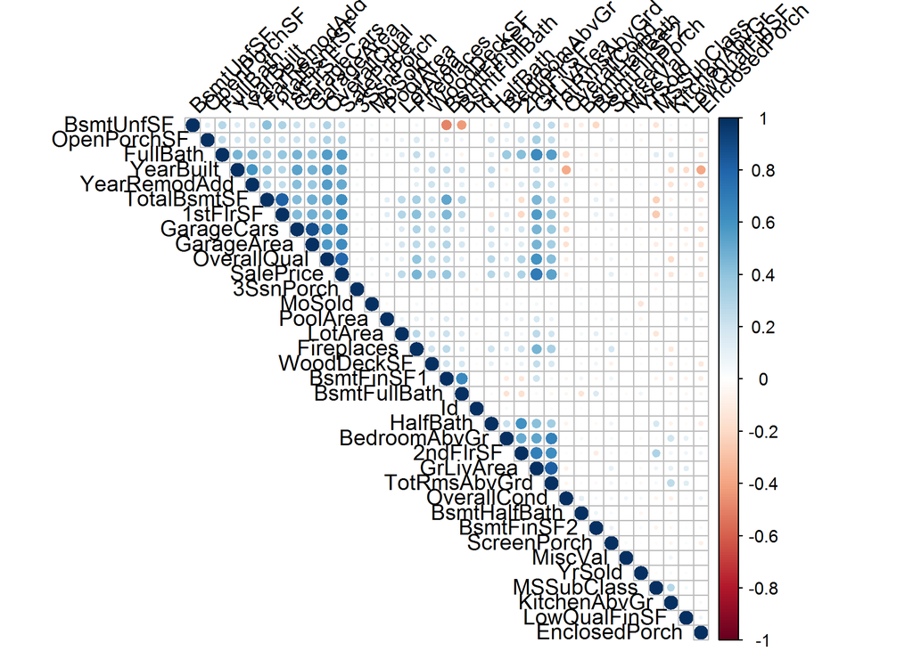

```r
corrplot(rcorr(as.matrix(n_q))$r, type = "upper", order = "hclust",tl.col = "black", tl.srt = 45)
```

```r
p_val = rcorr(as.matrix(n_q))$P

s = sort(p_val["SalePrice" , ])

s = s[1:10]   # what variables should we choose

x = c("LotArea" , "OverallQual" , "YearBuilt", "YearRemodAdd", "BsmtFinSF1" , "BsmtUnfSF" , "TotalBsmtSF" , "1stFlrSF" , "2ndFlrSF" , "GrLivArea")

m_cor = rcorr(as.matrix(n_q))$r["SalePrice" , x]

print(m_cor)
```

```
##      LotArea  OverallQual    YearBuilt YearRemodAdd   BsmtFinSF1
##    0.2638434    0.7909816    0.5228973    0.5071010    0.3864198
##    BsmtUnfSF  TotalBsmtSF     1stFlrSF     2ndFlrSF    GrLivArea
##    0.2144791    0.6135806    0.6058522    0.3193338    0.7086245
```

۲. در یک تصویر نمودار پراکنش دو به دو ده متغیر بدست آمده به همراه قیمت را رسم نمایید و هم خطی بودن متغیرها را بررسی کنید

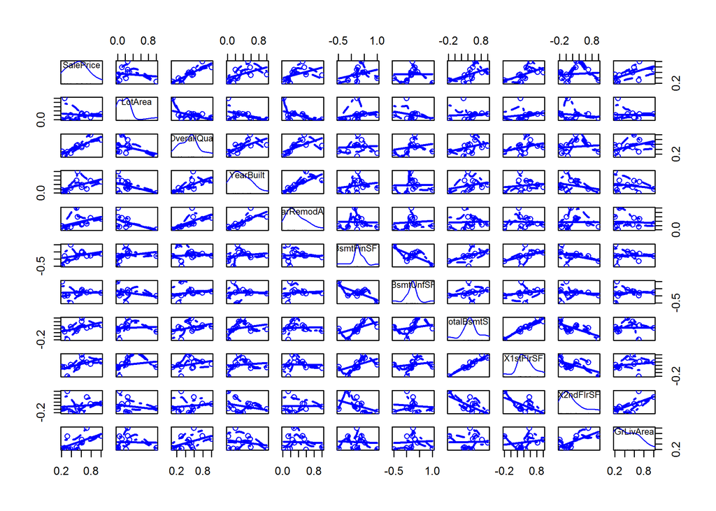

```r
scatterplotMatrix(cor(n_q %>% select(SalePrice , LotArea , OverallQual , YearBuilt , YearRemodAdd , BsmtFinSF1 ,BsmtUnfSF, TotalBsmtSF , `1stFlrSF` , `2ndFlrSF` , GrLivArea)))
```

۳. یک مدل خطی بر اساس ده متغیر برای پیش بینی قیمت برازش دهید. و سپس خلاصه نتایج مدل را به دست آورید.

```r
fit = lm(SalePrice ~ LotArea + OverallQual + YearBuilt + YearRemodAdd + BsmtFinSF1 + BsmtUnfSF + TotalBsmtSF + `1stFlrSF` + `2ndFlrSF` + GrLivArea, data = house)

summary(fit)
```

```
##
## Call:
## lm(formula = SalePrice ~ LotArea + OverallQual + YearBuilt +
##     YearRemodAdd + BsmtFinSF1 + BsmtUnfSF + TotalBsmtSF + `1stFlrSF` +
##     `2ndFlrSF` + GrLivArea, data = house)
##
## Residuals:
##     Min      1Q  Median      3Q     Max
## -560289  -17469   -1403   14495  280317
##
## Coefficients:
##                Estimate Std. Error t value Pr(>|t|)
## (Intercept)  -1.292e+06  1.171e+05 -11.030  < 2e-16 ***
## LotArea       5.946e-01  1.057e-01   5.623 2.24e-08 ***
## OverallQual   2.250e+04  1.158e+03  19.433  < 2e-16 ***
## YearBuilt     2.964e+02  4.592e+01   6.456 1.47e-10 ***
## YearRemodAdd  3.200e+02  6.258e+01   5.113 3.59e-07 ***
## BsmtFinSF1    1.362e+01  6.431e+00   2.118   0.0344 *
## BsmtUnfSF    -6.003e+00  6.266e+00  -0.958   0.3383
## TotalBsmtSF   1.522e+01  7.237e+00   2.103   0.0356 *
## `1stFlrSF`    5.076e+01  2.120e+01   2.394   0.0168 *
## `2ndFlrSF`    3.745e+01  2.094e+01   1.789   0.0739 .
## GrLivArea     1.248e+01  2.065e+01   0.604   0.5458
## ---
## Signif. codes:  0 '***' 0.001 '**' 0.01 '*' 0.05 '.' 0.1 ' ' 1
##
## Residual standard error: 37460 on 1449 degrees of freedom
## Multiple R-squared:  0.7792, Adjusted R-squared:  0.7776
## F-statistic: 511.2 on 10 and 1449 DF,  p-value: < 2.2e-16
```

۴. نمودار قیمت واقعی و قیمت پیش بینی را رسم نمایید و خوب بودن مدل را ارزیابی کنید.

```r
per = house %>% select(Id ,LotArea , OverallQual , YearBuilt , YearRemodAdd , BsmtFinSF1 ,BsmtUnfSF, TotalBsmtSF , `1stFlrSF` , `2ndFlrSF` , GrLivArea , SalePrice)

per = per %>% mutate(Predict_sale_price = predict(fit , house))
```

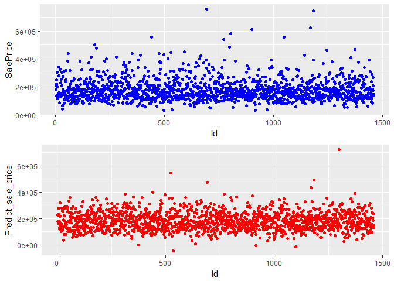

```r
ggplot(per , aes(x = Id , y = SalePrice)) + geom_point(color = "blue") -> a

ggplot(per) +  aes(x = Id , y = Predict_sale_price) + geom_point(color = "red") -> b


grid.arrange(a , b)
```

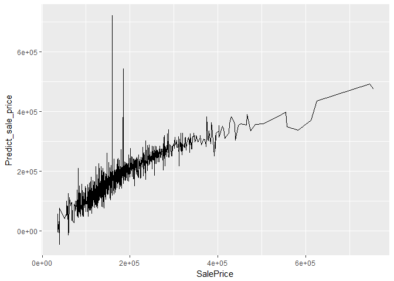

```r
ggplot(per) +  aes(x = SalePrice , y = Predict_sale_price ) + geom_line()
```

۵. مقدار R-squared مدل را به دست آورید. آیا بر اساس این کمیت مدل به خوبی به داده ها برازش داده شده است؟ کمیت F-statistic را در خلاصه مدل تفسیر نمایید.

```r
summary(fit)$r.squared
```

```
## [1] 0.7791569
```

با توجه به مقدار R_Squared می توان گفت داده ها به خوبی برازش شده اند.

در F-statistic داریم:

۶. بر اساس p-value سطح معناداری ضرایب تصمیم بگیرید که چه متغیرهایی در مدل سازی استفاده شود. بر اساس متغیرهای جدید دوباره مدل سازی کنید و نتایج رو گزارش دهید.

از مدل قبلی آن متغیر هایی که pvalue آن ها بدون ستاره بودند را حذف می کنیم.

```r
fit1 = lm(SalePrice ~ LotArea + OverallQual + YearBuilt + YearRemodAdd + BsmtFinSF1 + TotalBsmtSF + `1stFlrSF` , data = house)


summary(fit1)
```

```
##
## Call:
## lm(formula = SalePrice ~ LotArea + OverallQual + YearBuilt +
##     YearRemodAdd + BsmtFinSF1 + TotalBsmtSF + `1stFlrSF`, data = house)
##
## Residuals:
##     Min      1Q  Median      3Q     Max
## -459793  -22861   -2853   16459  354627
##
## Coefficients:
##                Estimate Std. Error t value Pr(>|t|)
## (Intercept)  -1.098e+06  1.287e+05  -8.526  < 2e-16 ***
## LotArea       9.121e-01  1.154e-01   7.902 5.39e-15 ***
## OverallQual   3.267e+04  1.124e+03  29.065  < 2e-16 ***
## YearBuilt     1.390e+02  4.932e+01   2.818   0.0049 **
## YearRemodAdd  3.708e+02  6.937e+01   5.345 1.05e-07 ***
## BsmtFinSF1    1.830e+01  2.838e+00   6.450 1.52e-10 ***
## TotalBsmtSF  -1.461e+00  4.813e+00  -0.304   0.7615
## `1stFlrSF`    4.569e+01  5.029e+00   9.086  < 2e-16 ***
## ---
## Signif. codes:  0 '***' 0.001 '**' 0.01 '*' 0.05 '.' 0.1 ' ' 1
##
## Residual standard error: 41610 on 1452 degrees of freedom
## Multiple R-squared:  0.727,  Adjusted R-squared:  0.7257
## F-statistic: 552.4 on 7 and 1452 DF,  p-value: < 2.2e-16
```

۷. مدل خود را بر اساس باقی مانده نقص یابی کنید. سه محک normality, independance, Constant Variance را در نقص یابی خود در نظر بگیرید.

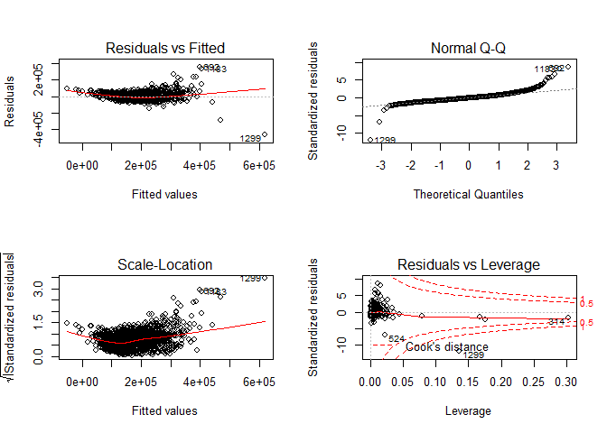

```r
#normality  &  Constant Variance

par(mfrow=c(2,2))

plot(fit1)
```

```r
#independance

dwtest(fit1)
```

```
##
##  Durbin-Watson test
##
## data:  fit1
## DW = 2.0105, p-value = 0.5802
## alternative hypothesis: true autocorrelation is greater than 0
```

۸. داده ها را به پنج قسمت تقسیم کنید. بر اساس چهار قسمت مدل خطی را بسازید و صحت مدل را برای یک قسمت باقی مانده را تست کنید. خطای پیش بینی شما چقدر است؟

```r
index = sample(x= 1:nrow(n_q),size = 0.8*nrow(n_q),replace = F)

a = n_q[index,]

b =  n_q[-index,]


#a = n_q[1:1168 , ]

#b = n_q[1169:1460 , ]

p_val1 = rcorr(as.matrix(a))$P

s1 = sort(p_val["SalePrice" , ])

s1 = s1[1:10]

x1 = c("LotArea" , "OverallQual" , "YearBuilt", "YearRemodAdd", "BsmtFinSF1" , "BsmtUnfSF" , "TotalBsmtSF" , "1stFlrSF" , "2ndFlrSF" , "GrLivArea")

fit_tr = lm(SalePrice ~ LotArea + OverallQual + YearBuilt + YearRemodAdd + BsmtFinSF1 + BsmtUnfSF + TotalBsmtSF + `1stFlrSF` + `2ndFlrSF` + GrLivArea, data = a)

#from p_val of variables we choose another model

fit_tr1 = lm(SalePrice ~ LotArea + OverallQual + YearBuilt + YearRemodAdd + BsmtFinSF1 + TotalBsmtSF , data = a)

b = b %>% mutate(Pre_Sale_Price = predict(fit_tr1 , b))


sum((b$SalePrice - b$Pre_Sale_Price)^2) -> err
err = err / 292
err = err^ 0.5

print(err)
```

```
## [1] 43397.39
```

۹. آیا قیمت ربط غیر خطی با یکی از ده متغیر استفاده شده دارد؟ بر اساس دستاوردهای خود مدل را بهتر نمایید.

```r
fit_pow_o = lm(SalePrice ~ LotArea + OverallQual + YearBuilt + YearRemodAdd + BsmtFinSF1 + TotalBsmtSF , data = per)

per_pow = per %>% mutate(Pre_pow_o = predict(fit_pow_o , per))

fit_pow = lm(SalePrice ~ I(LotArea^0.1) + OverallQual + I(YearBuilt^2) + I(YearRemodAdd^2) + BsmtFinSF1 + I(TotalBsmtSF^0.5) , data = per)

per_pow = per_pow %>% mutate(Pre_pow = predict(fit_pow , per))
```

۱۰. بر اساس مدل نهایی به دست آمده نتایج پیش بینی خود را بر روی test.csv به دست آورید و در سایت kaggle در مسابقه House Prices: Advanced Regression Techniques بارگذاری نمایید. سپس لینک رتبه و عدد آن را ضمیمه تمرین کنید.

```r
test = read_csv("D:/University/Semester8/Data analysis/week6/house/test.csv")
test =test %>% mutate(SalePrice = predict.lm(fit_pow_o , test))

out = test %>% select(Id , SalePrice)


write.csv(out , file = "C:/Users/MOHAMMAD AMIN/Desktop/gav.csv")
```

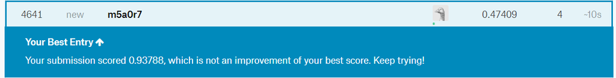